# Control Flow in Python

[Ahmed Moustafa](https://github.com/ahmedmoustafa)

# Please scan...

[figure not shown]

# Definition of Control Flow

- Control flow is the order in which statements and instructions are executed in a program
- Control flow can be affected by decision-making statements, loops, and function calls.

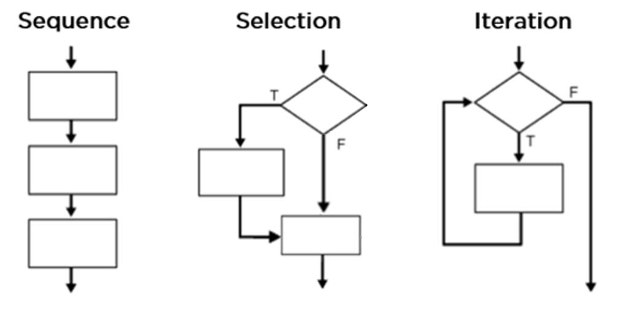

# Code blocks and indentation

- Code blocks are a group of statements that are executed together.
- In Python, code blocks are defined by their indentation level.

```python
%%script echo
if condition:
    # This code is indented, so it's part of the if block
    print('The condition is true.')

# This code is not indented, so it's not part of the if block
print('This code runs regardless of the condition.')
```

# If-else statements:

- If-else statements are used to execute code based on a condition.
- If the condition is true, the code within the if block is executed.
- If the condition is false, the code within the else block is executed.

Syntax:

```python
%%script echo
if condition:
    # Code to execute if the condition is true
else:
    # Code to execute if the condition is false
```

# If-else statements - Example

```python
age = 25
if age >= 18:
    print("You are an adult")
else:
    print("You are a minor")
```

```
You are an adult
```

You can also use a shorthand notation for assigning a value to a variable based on a condition:

```python
x = 10
y = 20
max_value = x if x > y else y
print(max_value)
```

```
20
```

# Boolean Operators

- Boolean operators are used to combine multiple conditions in an `if`-statement
- Python provides the operators `and`, `or`, and `not`

```python
x = 5
y = 10
if x > 0 and y < 20:
    print("Both conditions are true")
if x > 0 or y < 20:
    print("At least one condition is true")
if not x == y:
    print("x is not equal to y")
```

```
Both conditions are true
At least one condition is true
x is not equal to y
```

# Truth Table

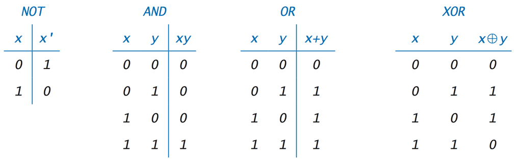

<sub>Source [Princeton's Introduction to CS: Boolean Logic](https://introcs.cs.princeton.edu/java/71boolean/)</sub>

# Boolean Operators with Non-boolean Values

Boolean operators can also be used with non-boolean values. In Python, any non-zero or non-empty value is considered true, while zero or empty values are considered false:

```python
name = ""
if not name:
    print("The name is not set")
```

```
The name is not set
```

# Nested If Statements

- Nested if statements allow for more complex conditions to be checked
- Multiple conditions can be checked using `if`, `elif`, and `else` statements inside of each other

Syntax:

```python
%%script echo
if condition1:
    if condition2:
        # Code to execute if both conditions are true
    else:
        # Code to execute if condition1 is true and condition2 is false
else:
    # Code to execute if condition1 is false
```

# Nested If Statements - Example

```python
grade = 85
if grade >= 90:
    print("You got an A")
elif grade >= 80:
    print("You got a B")
elif grade >= 70:
    print("You got a C")
else:
    print("You failed the course")
```

```
You got a B
```

# Loops: `for`

`for` loops are used to iterate over a sequence of items. Syntax:

```python
%%script echo
for item in sequence:
    # Code to execute for each item in the sequence
```

```python
fruits = ['apple', 'banana', 'cherry']
for fruit in fruits:
    print(fruit)
```

```
apple
banana
cherry
```

# Loops: `while`

- `while` loops are used to repeat a block of code while a certain condition is true.

Syntax:

```python
%%script echo
while condition:
    # Code to execute as long as the condition is true
```

# Loops: `while` - Example

```python
x = 0
while x < 5:
    print(x)
    x += 1
```

```
0
1
2
3
4
```

# `continue` and `break` Statements

- `continue` statements are used to skip to the next iteration of a loop.
- `break` statements are used to exit a loop early.

```python
%%script echo
for item in sequence:
    if condition:
        continue # Skip to the next iteration
    if other_condition:
        break # Exit the loop early
    # Code to execute for each item in the sequence
```

# `continue` and `break` Statements - Example

```python
fruits = ['apple', 'banana', 'cherry']
for fruit in fruits:
    if fruit == 'banana':
        continue # Skip printing "banana"
    if fruit == 'cherry':
        break # Exit the loop
    print(fruit)
```

```
apple
```

# Exercise: Fibonacci Sequence

Write a program that generates the first 20 numbers in the Fibonacci sequence.

**Hints:**

- The Fibonacci sequence is a sequence of numbers where each number is the sum of the two preceding numbers.
- The first two numbers in the sequence are 0 and 1.
- Use a for loop to generate the sequence.

**Example output:**

0, 1, 1, 2, 3, 5, 8, 13, 21, 34, 55, 89, 144, 233, 377, 610, 987, 1597, 2584, 4181

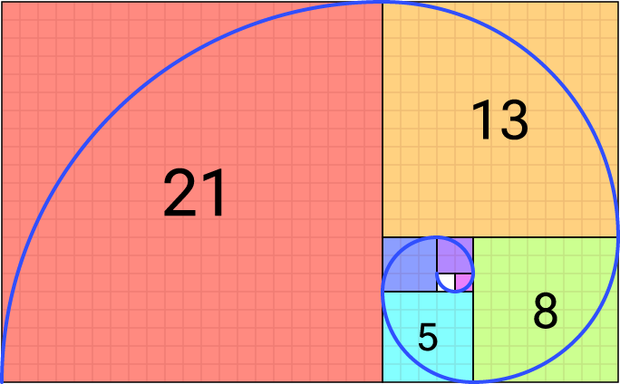

# Exercise: Fibonacci Sequence (GitHub)

[figure not shown]

# Summary

Python provides several control flow statements to manage the order of execution of code, including if-else statements, nested if statements, for loops, while loops, break statements, and continue statements. These statements allow data scientists to write more efficient and effective code.